[figure not shown]

# Android Fundamentals

## Unit 1: Get started

## 2.3 Implicit Intents

- Introduction
- What you'll learn
- What you'll do

#### Tasks

- Task 1: Create the project and layout
- Task 2: Implement the Open Website button
- Task 3: Implement the Open Location button
- Task 4: Implement the Share This Text button

[Vocabulary words and concepts glossary](https://developers.google.com/android/for-all/vocab-words/)

1. Introduction

In a previous section you learned about explicit intents. In an explicit intent, you carry out an activity in your app, or in a different app, by sending an intent with the fully qualified class name of the activity. In this section you learn more about implicit intents and how to use them to carry out activities.

With an implicit intent, you initiate an activity without knowing which app or activity will handle the task. For example, if you want your app to take a photo, send email, or display a location on a map, you typically don't care which app or activity performs the task.

> You should be able to:
> - Use the layout editor to modify a layout.
> - Edit the XML code of a layout.
> - Add a Button and a click handler.
> - Create and use an Activity.
> - Create and send an Intent between one Activity and another.
1. What you'll learn
   - How to create an implicit Intent, and use its actions and categories.
   - How to use the ShareCompat.IntentBuilder helper class to create an implicit Intent for sharing data.
   - How to advertise that your app can accept an implicit Intent by declaring Intent filters in the AndroidManifest.xml file.
1. What you'll do
   - Create a new app to experiment with implicit Intent.
   - Implement an implicit Intent that opens a web page, and another that opens a location on a map.
   - Implement an action to share a snippet of text.
   - Create a new app that can accept an implicit Intent for opening a web page.

## App overview

In this section you create a new app with one Activity and three options for actions: open a web site, open a location on a map, and share a snippet of text. All of the text fields are editable (EditText), but contain default values.

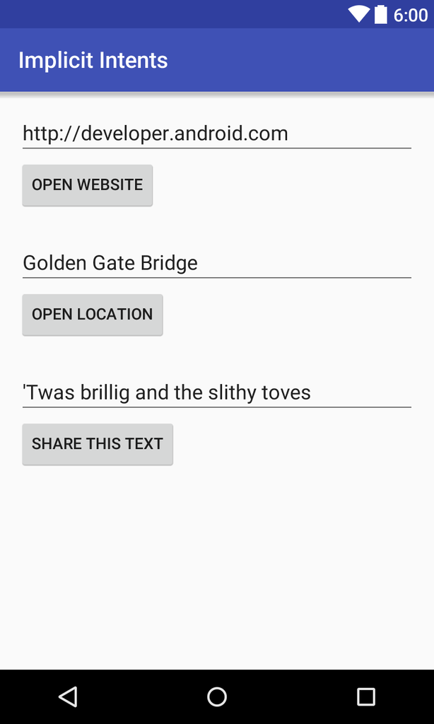

## Task 1: Create the project and layout

#### 1.1 Create the project

#### 1.2 Create the layout

## Task 2: Implement the Open Website button

#### 2.1 Define openWebsite()

#### 2.2 Add code to openWebsite()

## Task 3: Implement the Open Location button

#### 3.1 Define openLocation()

#### 3.2 Add code to openLocation()

## Task 4: Implement the Share This Text button

#### 4.1 Define shareText()

#### 4.2 Add code to shareText()

#### 4.3 Run the app

[figure not shown]

[figure not shown]

[figure not shown]

## [ImplicitIntents - Solution Code](https://github.com/google-developer-training/android-fundamentals-apps-v2/tree/master/ImplicitIntents)

## Task 5: Receive an implicit Intent

#### 5.1 Create the project and layout

#### 5.2 Modify AndroidManifest.xml to add an Intent filter

#### 5.3 Process the Intent

#### 5.4 Run both apps

## [Task 5 solution code - implicit Receiver](https://github.com/google-developer-training/android-fundamentals-apps-v2/tree/master/ImplicitIntentsReceiver)

## Coding challenge

**Challenge:** In a previous practical challenge you created a shopping list app builder with an Activity to display the list, and another Activity to pick an item. Add an EditText and a Button to the shopping list Activity to locate a particular store on a map.